# Analysis LR field of 10x Visium Mouse Brain dataset using spWAVE

Kai Li

2025-04-07 (updated 2026-09-24)

In this vignette, we will start with a mouse brain 10x Visium dataset, and show the steps of field estimation and result visualization. This vignette is mainly designing for analysis low resolution or small cell number (cells < 10000) ST dataset, like 10x Visuim, Slide-Seq and Stereo-seq. Those ST techniques are usually high transcripts coverage with small cell number, resulting in a relative smaller distance matrix but providing more transcription information. Thus we directly process the distance matrix and pass it to the field estimation function. For a dataset with large number of cells, the dense distance matrix will take too much memory and resource. We use another distance-based simplification method to process the large dataset. For more details, please check another tutorial Analysis LR field of large dataset using spWAVE .  
Let’s start by loading the required libraries and data. ## Setup and Pre-processing ST expression and LR database data ### Load the required libraries

```r
library(magrittr)
library(dplyr)
library(tidyr)
library(stringr)

library(Seurat)
library(Matrix)
library(ggplot2)
library(spWAVE)
```

### Load the mouse brain 10x Visium dataset

First, we load a pre-processed 10x Visium dataset of mouse brain. The rawdata of this dataset can be downloaded from [10x Visium](https://www.10xgenomics.com/cn/datasets/mouse-brain-serial-section-1-sagittal-posterior-1-standard-1-0-0) Or load the data from ‘SeuratData’ package, by running the following code:

```r
library(SeuratData)
InstallData("stxBrain")
brain <- LoadData("stxBrain", type = "posterior1")
```

Here the brain data has been already processed with the standard workflow of Seurat. The default assay was set as ‘SCT’, and the clustering method is “leiden”, which is a little different from ‘SeuratData’ dataset.

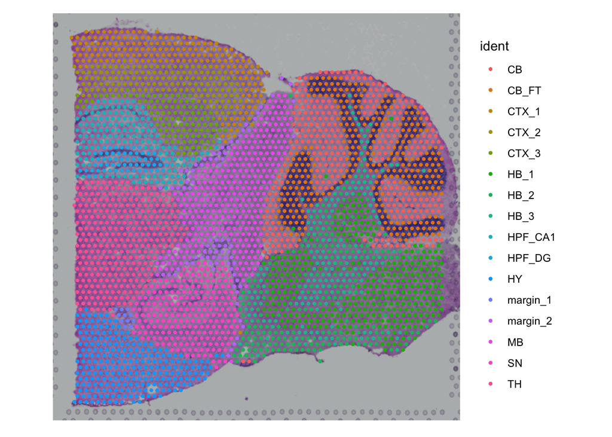

```r
#** folder holding the tutorial dataset, adjust it to your local copy
data_dir <- "../../data"
brain <- readRDS(file.path(data_dir, "mouse_brain_anno_clu.rds"))
SpatialDimPlot(brain)
```

**assign custom color**

Here, we can use a custom color palette for each cluster. Alternatively, spWAVE provides a built-in color palette if not manually given.

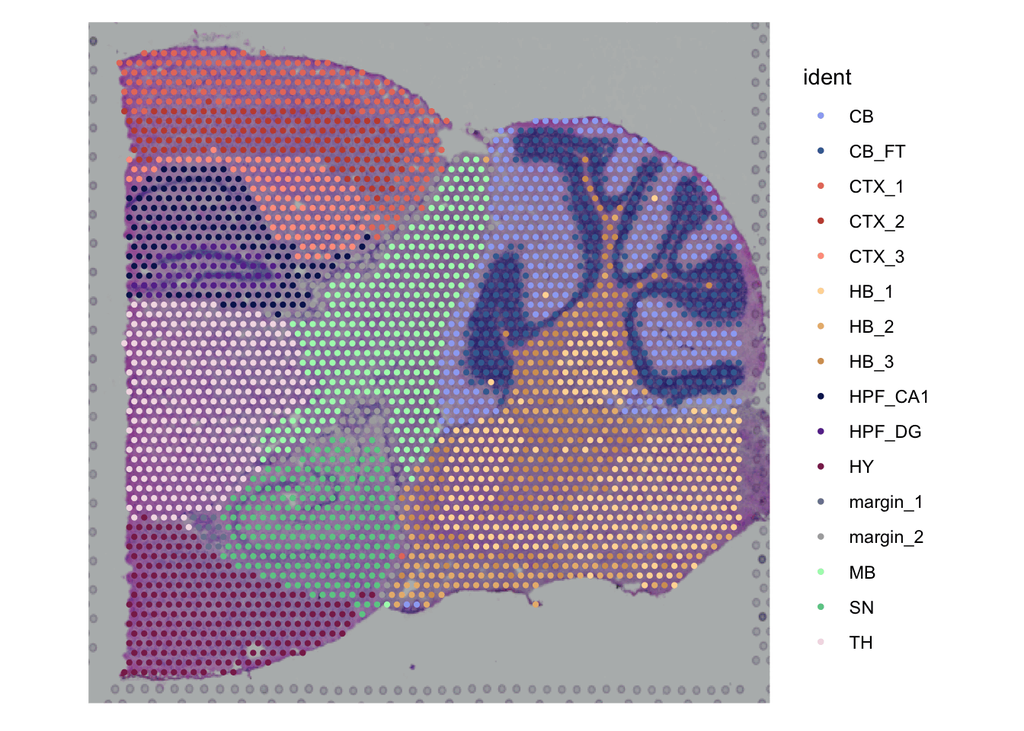

```r
manual_colors <- c(
  "CB"       = "#9CACF3",
  "CB_FT"    = "#406DA0",
  "CTX_1"    = "#E67A6A",
  "CTX_2"    = "#C44E3E",
  "CTX_3"    = "#FF9E8C",
  "HB_2"     = "#E8B87C",
  "HB_3"     = "#D49E60",
  "HB_1"     = "#FFD9A3",
  "HPF_CA1"  = "#081D5B",
  "HPF_DG"   = "#663399",
  "HY"       = "#892958",
  "margin_1" = "#778899",
  "margin_2" = "#ACACAC",
  "MB"       = "#AAF9BA",
  "SN"       = "#6BCB94",
  "TH"       = "#F3DDE5"
)

SpatialDimPlot(brain,cols=manual_colors)
```

Now, we create the spWAVE S4 class object by two methods. ### Create spWAVE object from one line command We can easily create the object through the “create_spWAVE_object” function for a Seurat V5 dataset, as the following code:

```r
mouse_db <-
    load_database(db_source = "CellChat",db_species = "mouse",filter_type = "Secreted")
#** here, we will use a smaller subset to show the example
mouse_db %<>% dplyr::filter(Family %in% c("TGFb","FGF"))
brain_spWAVE <- create_spWAVE_object(brain,mouse_db,assay = "SCT")
```

**Note**: The default expression assay is ‘SCT’. You can change it by setting the ‘assay’ argument, even using raw counts data. Despite this method is robust for counts, we do recommend to use a normalized data like “SCT” or others which reduced the technical variance.

### Mannually create spWAVE object

We also provided a alternative mehtod for manually creating spWAVE object, which you can use lower Seurat version or other data structure of ST dataset.

However, we still need the Seurat object as input to extract expression matrix. You can just transform or create a Seurat object only with the expression data, and mannually giving the coordinates and cluster information to spWAVE.

First, we filter the ligand-receptor database, same as the above.

```r
mouse_db <-
    load_database(db_source = "CellChat",db_species = "mouse",filter_type = "Secreted")
#** here, we will use a smaller subset to show the example
mouse_db %<>% dplyr::filter(Family %in% c("TGFb","FGF"))
```

And just for showcase, we directly extract the spatial coordinates from the Seurat object. For a custom coordinates input, please make sure the spatial units are in the micrometer, otherwise the scales of field quanties would be weird.

```r
brain_coord <- get_coordinates(brain)
#** preview the spatial coordinates
head(brain_coord)
```

```
#>                           y        x            barcode
#> AAACAAGTATCTCCCA-1 4607.621 6213.208 AAACAAGTATCTCCCA-1
#> AAACACCAATAACTGC-1 3824.797 2063.081 AAACACCAATAACTGC-1
#> AAACAGCTTTCAGAAG-1 5216.887 1562.742 AAACAGCTTTCAGAAG-1
#> AAACAGGGTCTATATT-1 4868.320 1763.168 AAACAGGGTCTATATT-1
#> AAACAGTGTTCCTGGG-1 2606.265 3262.733 AAACAGTGTTCCTGGG-1
#> AAACATTTCCCGGATT-1 3650.514 5963.401 AAACATTTCCCGGATT-1
```

```r
brain_spWAVE <-
  create_spWAVE_object(
      seurat_obj=brain,
      assay="SCT",
      database=mouse_db,
      coord=brain_coord,
      cluster=NULL
      )
```

Here, the expression matrix is still extracted from Seurat object, regradless the version. And the coordinates of the cells can be manually given by users. For custom coordinates input, the input should be a data.frame with three columns. The colnames must be “x”,“y” and “barcode” as the result shown, literally. And the rownames must be definitely same with the colnames of expression matrix stored in Seurat object, both the order and names of cells.

Further, the cluster info will be automatically extracted from the ‘active.ident’ of the Seurat object if not given. You can provide a character which is the colname of Seurat metadata to define the cluster info. Otherwise, a data.frame with two columns, “cluster” and “barcode” can be provided.

## Perform the vector field estimation and interaction scoring

```r
#** one line command
#** (plain `<-` rather than `%<>%` here: knitr only recognises `<-`/`=` when
#** deciding which objects belong in the cache, so `%<>%` caches nothing)
brain_spWAVE <- brain_spWAVE %>% perform_LR_field_calc()
```

```
#> [1] "Step1. calc single molecule or complex field"
#> [1] "Step2. calc LR pair or family field"
#>   |                                                                              |                                                                      |   0%  |                                                                              |==                                                       …
#>   |                                                                              |                                                                      |   0%  |                                                                              |===================================                      …
```

```r
brain_spWAVE <- brain_spWAVE %>% perform_S2S_score_calc()
```

```
#> [1] "Step1. preparing data"
#>   |                                                                              |                                                                      |   0%  |                                                                              |==                                                       …
#> [1] "Step2. calc S2S force"
#> [1] "Step3. calc S2S score"
#>   |                                                                              |                                                                      |   0%  |                                                                              |==                                                       …
```

```r
brain_spWAVE <- brain_spWAVE %>% perform_C2C_score_calc(shuffle_iter=200,verbose=T)
```

Since the “perform_S2S_score_calc” is resource and time consuming, we can save the intermediate results before next step. For the a dataset with large number of cells, storing the S2S score will take too much memory and disk space. Therofore, after finishing the running the C2C score, we can diet it and save it without the S2S score.

```r
brain_spWAVE@S2S_score <- list()
gc()
saveRDS(brain_spWAVE,"path/you/like.rds")
```

## Perform with ‘future’ multi-threading

In this section, we will use the ‘future’ package to run the perfromance in parallel. However, please remind that the “perform_S2S_score_calc” is resource and time consuming, cafefully determining the number of threads and the memory size of each thread.

```r
library(future)
library(future.apply)
library(pbapply)

plan("multisession",workers=4)
options(future.globals.maxSize = 6*1024^3)
#e.g. we want to use 4 threads, and per session memory is 6GB

brain_spWAVE %<>% perform_LR_field_calc()
brain_spWAVE %<>% perform_S2S_score_calc()
brain_spWAVE %<>% perform_C2C_score_calc(shuffle_iter=200,verbose=T)
```

## Visualization

In this section, we will use the spWAVE output to visualize the results.

### The vector field projection

Now we can plot certain LR interaction field, let’s start with “Fgf1-Fgfr1”. First, we need to extract the LR field info from database result. And we will display two mode of field projection: point mode and grid mode.

```r
library(patchwork)
brain_Fgf1 <-  perform_field_extract(brain_spWAVE,"Fgf1.Fgfr1")
brain_Fgf1 %>% head
```

```
#>                           y        x            barcode            Ex
#> AAACAAGTATCTCCCA-1 4607.621 6213.208 AAACAAGTATCTCCCA-1  4.400470e-04
#> AAACACCAATAACTGC-1 3824.797 2063.081 AAACACCAATAACTGC-1  1.848817e-04
#> AAACAGCTTTCAGAAG-1 5216.887 1562.742 AAACAGCTTTCAGAAG-1  1.311554e-04
#> AAACAGGGTCTATATT-1 4868.320 1763.168 AAACAGGGTCTATATT-1 -7.469621e-05
#> AAACAGTGTTCCTGGG-1 2606.265 3262.733 AAACAGTGTTCCTGGG-1 -1.144690e-04
#> AAACATTTCCCGGATT-1 3650.514 5963.401 AAACATTTCCCGGATT-1 -1.029766e-04
#>                               Ey           U      Fgf1     Fgfr1 Rel_LR_Exp
#> AAACAAGTATCTCCCA-1  0.0002181545  0.14009258 1.3862944 0.6931472  0.6931472
#> AAACACCAATAACTGC-1 -0.0005181574  0.00904740 0.6931472 0.6931472  0.0000000
#> AAACAGCTTTCAGAAG-1  0.0002395317 -0.03772395 1.0986123 0.0000000  1.0986123
#> AAACAGGGTCTATATT-1 -0.0002256145  0.05111014 0.6931472 0.0000000  0.6931472
#> AAACAGTGTTCCTGGG-1  0.0000195163 -0.08352131 0.0000000 0.6931472 -0.6931472
#> AAACATTTCCCGGATT-1 -0.0004868262  0.09508120 0.0000000 1.3862944 -1.3862944
#>                              KEx           KEy   E_strength            KU
#> AAACAAGTATCTCCCA-1  3.501782e-05  1.736018e-05 3.908483e-05  0.0111482131
#> AAACACCAATAACTGC-1  1.471242e-05 -4.123366e-05 4.377979e-05  0.0007199692
#> AAACAGCTTTCAGAAG-1  1.043702e-05  1.906132e-05 2.173167e-05 -0.0030019769
#> AAACAGGGTCTATATT-1 -5.944136e-06 -1.795383e-05 1.891224e-05  0.0040672158
#> AAACAGTGTTCCTGGG-1 -9.109151e-06  1.553058e-06 9.240597e-06 -0.0066464151
#> AAACATTTCCCGGATT-1 -8.194620e-06 -3.874040e-05 3.959761e-05  0.0075663212
```

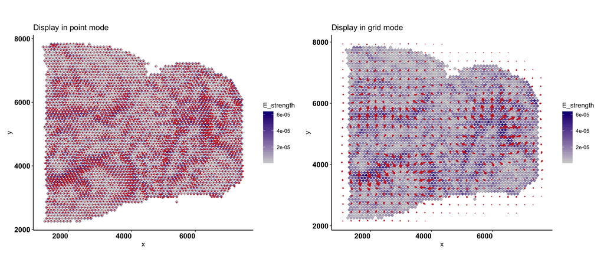

```r
p1 <- plot_field_direction2(brain_Fgf1,point_size = 2,mode="point",arrow_sf=1.5)+
  labs(title = "Display in point mode")
p2 <- plot_field_direction2(brain_Fgf1,point_size = 2,mode="grid")+
  labs(title = "Display in grid mode")
p1|p2
```

Both “point” and “grid” mode show vector field with similar pattern. However, the “point” mode seems cluttered with too many arrows, we recommend using the “grid” mode and it is the default option.

We can specify particular data which is the column names of the data.frame to change the data displayed in the point. With ggplot2 setting, we can give a two-color scale gradiant to display two-directional value.

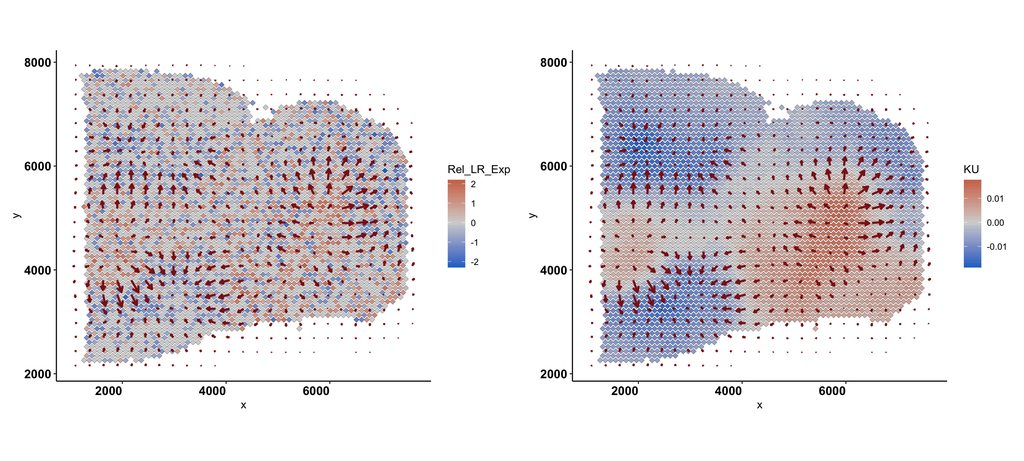

```r
p3 <- plot_field_direction2(brain_Fgf1,point = "Rel_LR_Exp",
        point_size = 2,arrow_color = "firebrick4")+
          scale_fill_gradient2(low="dodgerblue3", mid="lightgray",high="salmon3")
p4 <- plot_field_direction2(brain_Fgf1,point = "KU",
        point_size = 2,arrow_color = "firebrick4")+
          scale_fill_gradient2(low="dodgerblue3", mid="lightgray",high="salmon3")
p3|p4
```

In this figure, the “Rel_LR_Exp” represent the relative Ligand-Recptor expression, which the postive is the ligand and negative is the receptor, repestively. The “KU” is the value of the field potential matching with the “Rel_LR_Exp”, displaying the pattern of the LR spatial distribution.

Here, we show the ability to display the other quantities of the field projection function. The quantity should be a column in the field result data.frame. You can manually add columns after extraction the field info and giving the col.name to the ‘point’ argument.

Further, the argument ‘point’ is also accepting a discrete variable like factors or characters, e.g. cluster or group info, which stored in the data.frame. We will show it in another tutorial which handling the large number cells dataset, like the single cell resolution 10x Xenium ST dataset.

Next, we can plot the field over the HE image or cluster info, by changing the image parameter and giving seurat object, which contains the background info. The cluster infos are extracted from the ‘active.ident’ of the seurat object.

```r
p5 <- plot_field_direction2(brain_Fgf1,
        seurat_obj = brain,
        image="HE",mode='grid'
        ) + NoLegend()
```

```
#> replace the existing one.
```

```r
p6 <- plot_field_direction2(brain_Fgf1,
        seurat_obj = brain,
        image="cluster",mode='grid')
```

```
#> replace the existing one.
```

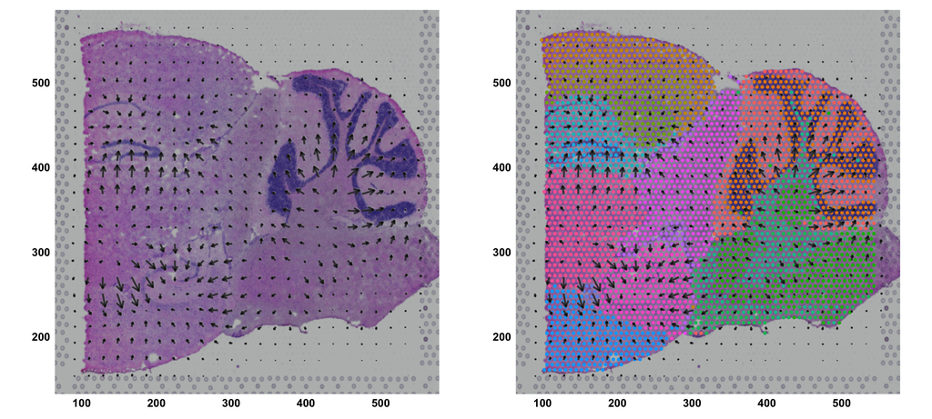

```r
p5|p6
```

Here, because of the Seurat plotting behavior, the coordinates in plot will change to lo-res image based, to match the Seurat plotting functions.

We first overview all interaction using heatmap and network plot.

### Heatmap

The heatmap is suitable to show the sender and receiver cluster relationship.

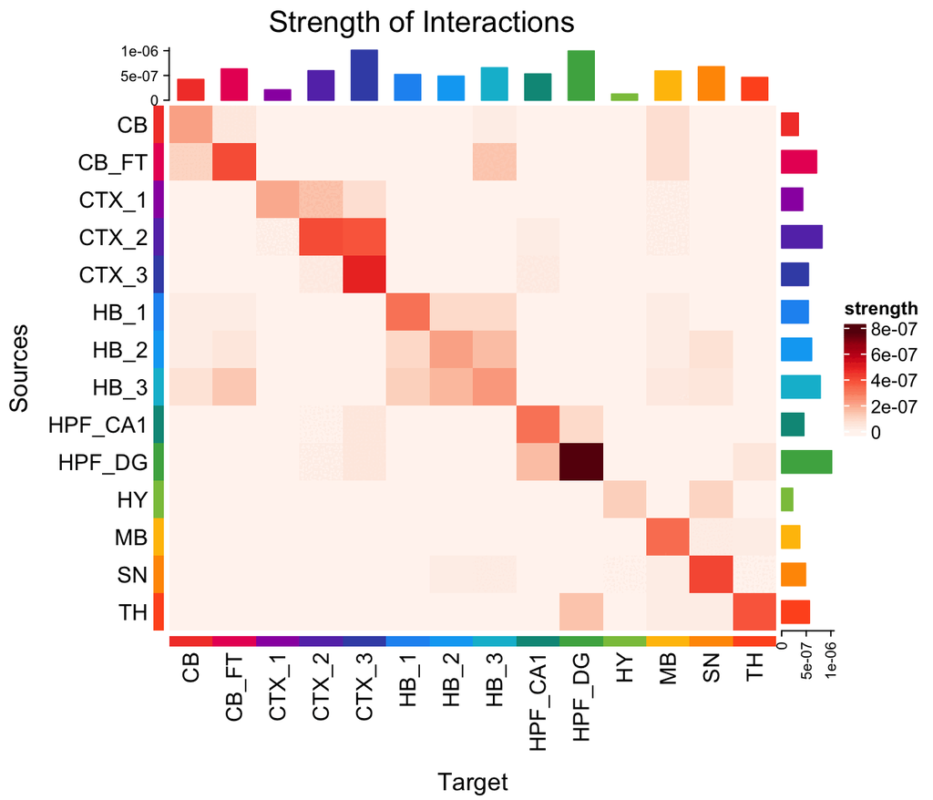

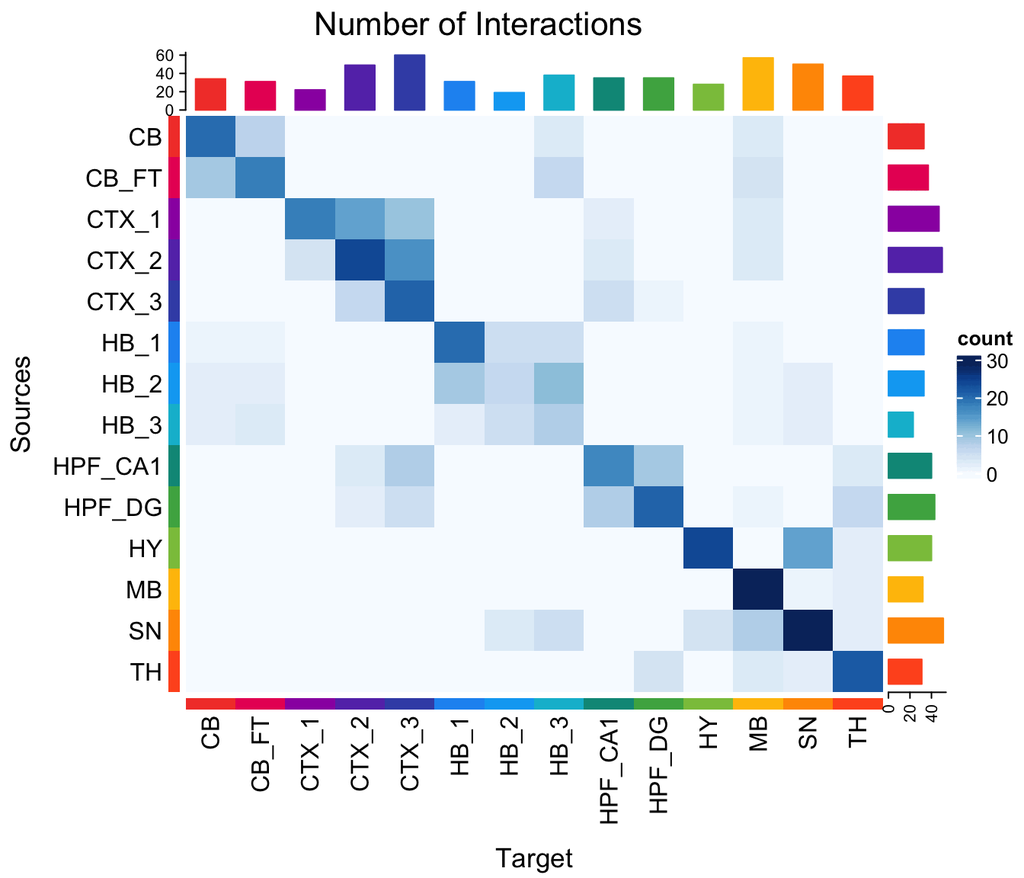

```r
#filter out the margin cluster
clu_use <- brain@active.ident %>% levels()
clu_use <- clu_use[-c(12,13)]

plot_LR_cluster_heatmap(
  brain_spWAVE,
  #cluster_color=manual_colors,
  method_use="strength",
  source_use=clu_use,
  target_use=clu_use
)

plot_LR_cluster_heatmap(
  brain_spWAVE,
  #cluster_color=manual_colors,
  method_use="count",
  source_use=clu_use,
  target_use=clu_use,
  ht_col="Blues"
)
```

As the code shown, we can select and filter the clusters by argments “source_use” and “target_use”. And the parameter “method_use” is used to choose the type of data. The “count” means the number of interactions, while the “strength” means the sum of interaction strength between the clusters.

### Network Diagram

Similarly, we can plot the network using the same parameters, but this time we focus on the FGF family.

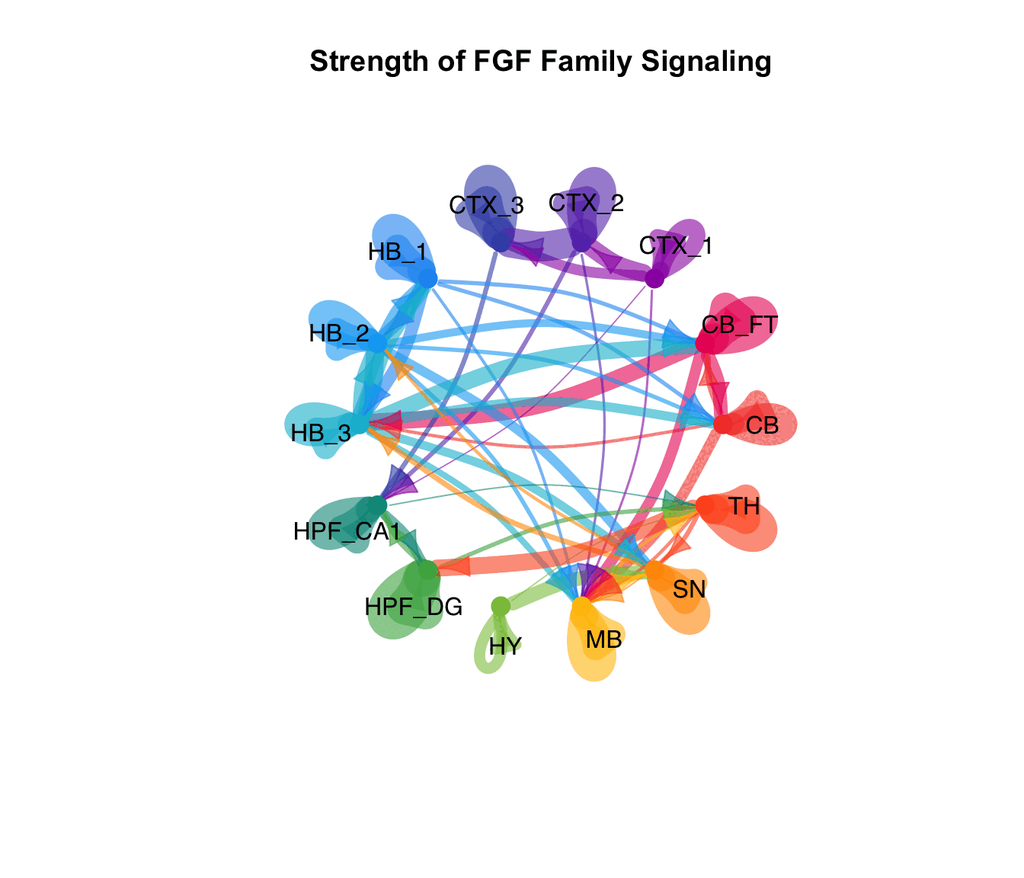

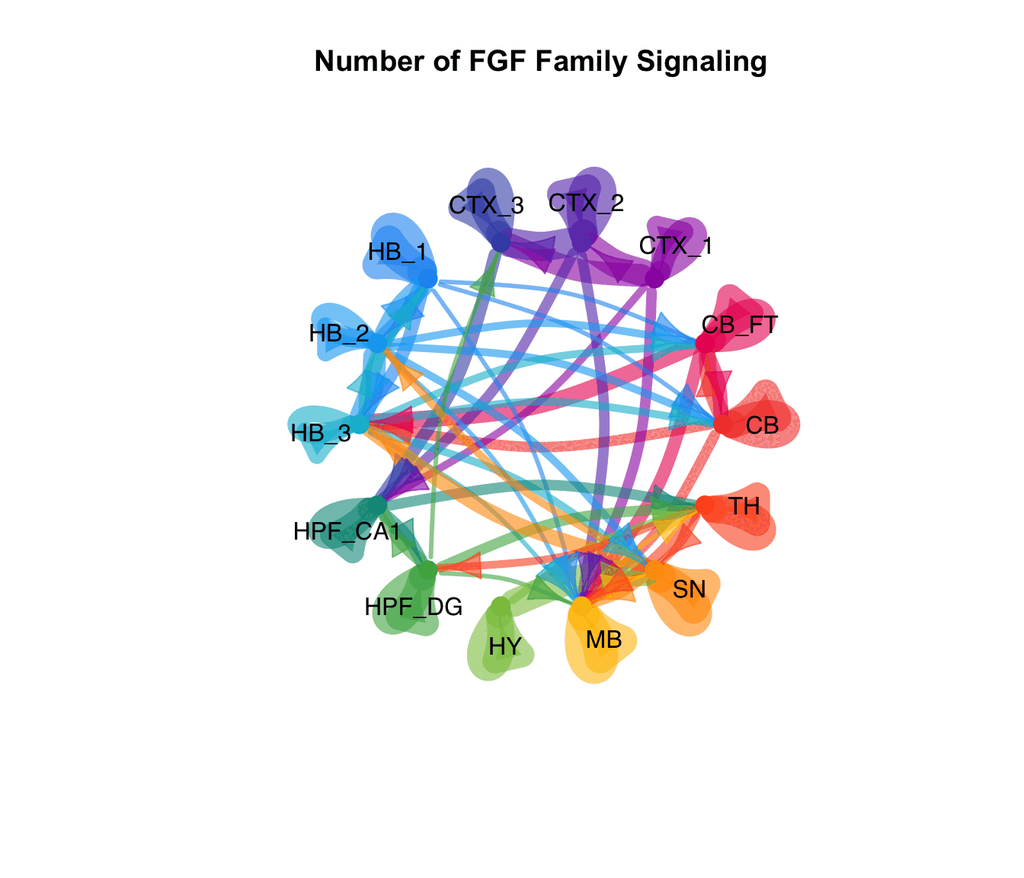

```r
plot_LR_cluster_net(
  brain_spWAVE,
  #cluster_color=manual_colors,
  LR_family="FGF",
  method_use="strength",
  cluster_use=clu_use,
  mat_scale=TRUE,
  #weight.scale=TRUE
)

plot_LR_cluster_net(
  brain_spWAVE,
  #cluster_color=manual_colors,
  LR_family="FGF",
  method_use="count",
  cluster_use=clu_use,
  mat_scale=TRUE,
  #weight.scale=TRUE
)
```

Same like other plot, we can determine the cluster and interacion we interested to show. But here is a little different, we use ‘cluster_use’ which intergrating the ‘source_use’ and ‘target_use’, because there are nodes and directional lines in the network and not simply presented as the ‘sender’ or ‘recevier’.

Here, we summary the argments that helping manipulate data crossing visualization functions as below:

| Function Type | Arguments | note |
| --- | --- | --- |
| LR filter | “LR”, “LR_pair”, “LR_family” |  |
| Cluster filter | “cluster_use”, “target_use”, “source_use” |  |
| Statstic | “method_use” | only “count” or “strength” |

And for more details, please refer to the corresponding plot function.

Maybe you have already noticed the title. It can be auto-generated under certain conditions, depending on the ‘method_use’, ‘LR_family’ and ‘LR_pair’. Also, we can change the title manually by giving characters to ‘title’ parameter.

### Chord Diagram

Chord diagram is also a good way to show the relationship between the sender and receiver. Especially, it display the clear relative strength between the clusters. Here, for clearly displaying, we only using the HB and CB clusters to show two different chord diagrams, one for clusters and one for genes.

```r
CB_HB_clu <- c("CB", "CB_FT", "HB_1", "HB_2", "HB_3")

FGF_color <- c(
  "Fgf1"="#3F51B4",
  "Fgf7"="#02A9F3",
  "Fgfr1"="#4CAE50",
  "Fgfr2"="#CCDC39",
  "Fgfr3"="#FFC006",
  "Fgf9"="#F34335",
  "Fgf2"="#E91E63",
  "Fgf10"="#9B26B0",
  "Fgf5"="#009687",
  "Fgf22"="#8BC34A",
  "Fgf18"="#FFEB3A"
)

plot_LR_gene_chord(brain_spWAVE,
  LR_family="FGF",
  source_use=CB_HB_clu,
  target_use=CB_HB_clu,
  LR_color=FGF_color
  )
```

```
#> The '.' in the 'cluster' will be transformed to '_' in case of conflicting with LR
```

```
#> The clusters in plot will follow the order of cluster_color names.
```

[figure not shown]

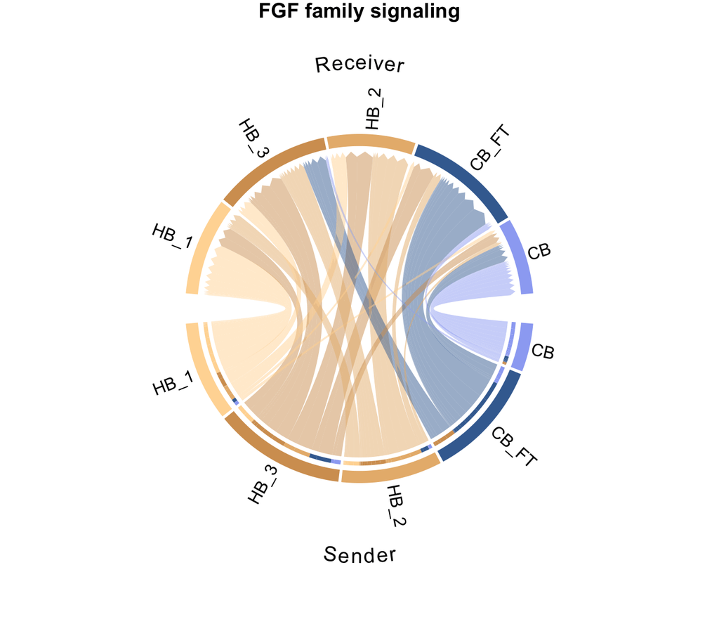

```r
plot_LR_cluster_chord(brain_spWAVE,
  cluster_color=manual_colors,
  LR_family="FGF",
  source_use=CB_HB_clu,
  target_use=CB_HB_clu
  )
```

### Dot Plot

Further, we can also use dot plot to quickly show multiple the interactions between the clusters. Same like above, we only use HB and CB clusters.

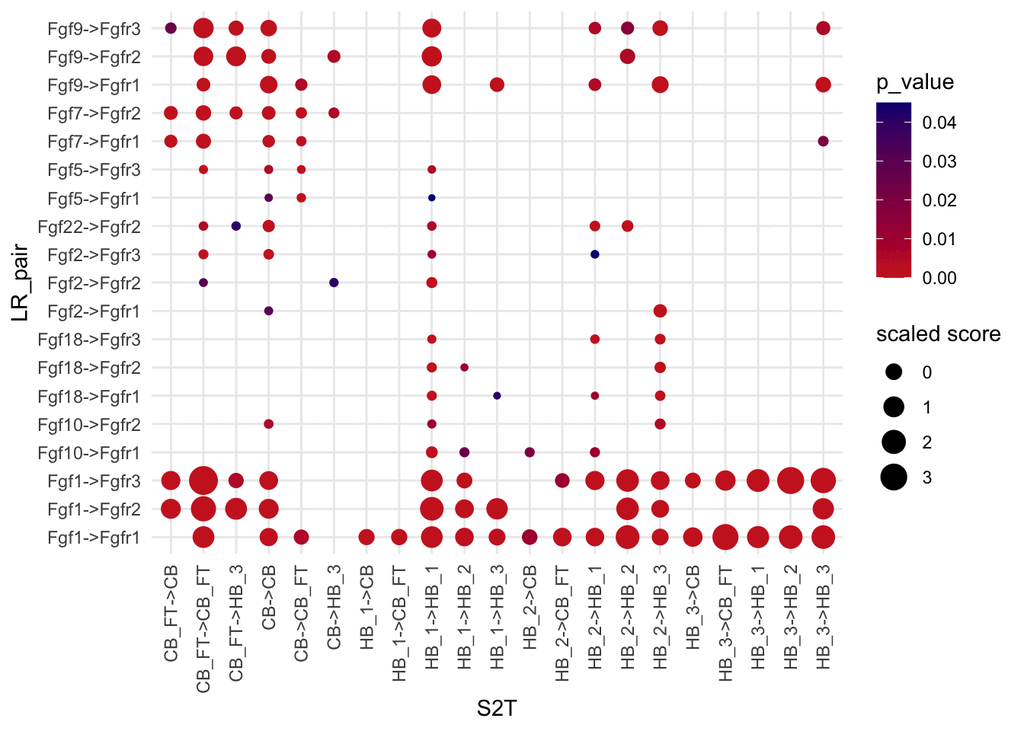

```r
plot_db_score_dot(brain_spWAVE,
  p_val=0.05,
  source_use=CB_HB_clu,
  target_use=CB_HB_clu,
  LR_family='FGF'
)
```